## Red Wine Quality Analysis by Travis Moore

##### This dataset contains nearly 1600 observations across 13 variables. The goal of this analysis is to understand what factors, if any, contribute to wine quality ratings.

```
##  [1] "X"                    "fixed.acidity"        "volatile.acidity"
##  [4] "citric.acid"          "residual.sugar"       "chlorides"
##  [7] "free.sulfur.dioxide"  "total.sulfur.dioxide" "density"
## [10] "pH"                   "sulphates"            "alcohol"
## [13] "quality"
```

### Histogram of Wine Quality Rating

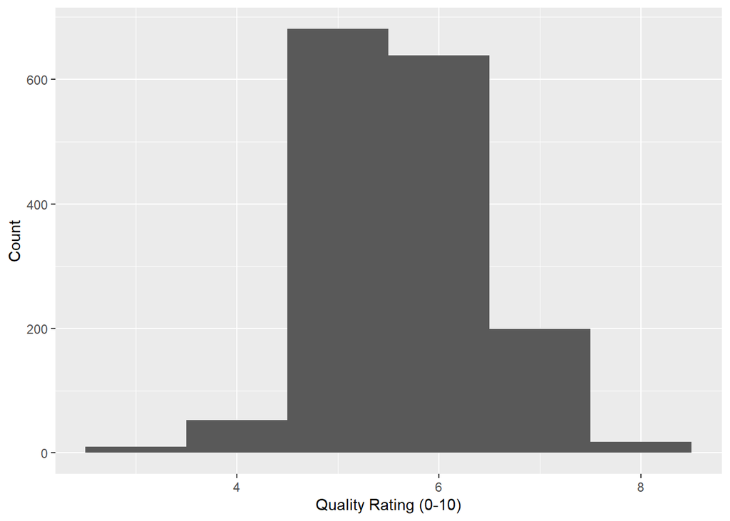

```
##    Min. 1st Qu.  Median    Mean 3rd Qu.    Max.
##   3.000   5.000   6.000   5.636   6.000   8.000
```

##### I chose a bar chart so we can easily what the wines in the dataset are rated. A majority of our wines’ ratings were between 5 and 8.

### Alcohol Content

#### Bar Chart

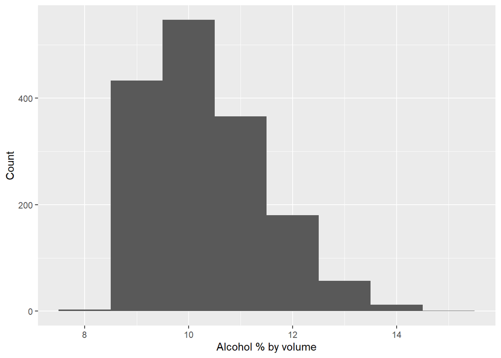

##### I chose a bar chart so we can easily what the alcohol content of wines in the dataset.

#### Box Plot with Category Summaries

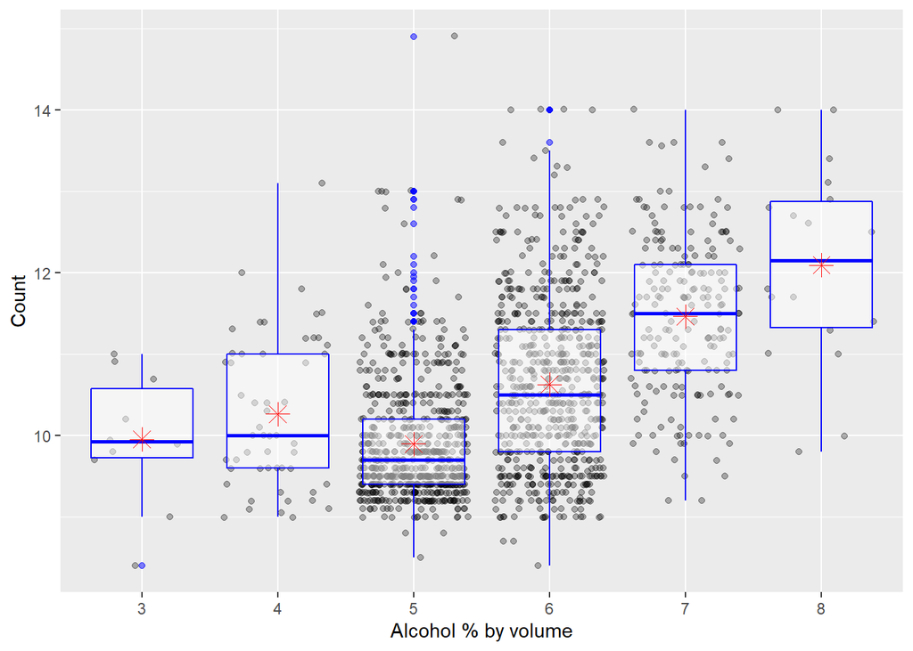

##### The higher the alcohol content the higher the rating.

### Fixed Acidity

#### Bar Chart

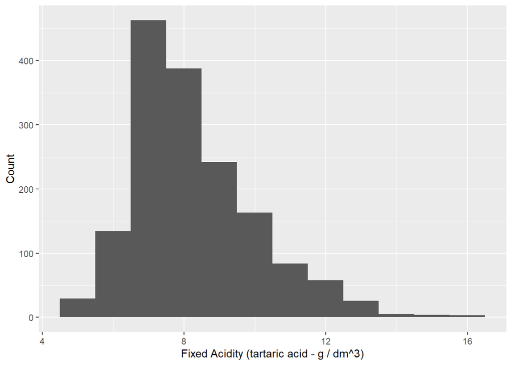

##### I chose a bar chart so we can easily what the fixed acidity content of wines in the dataset.

#### Box Plot with Category Summaries

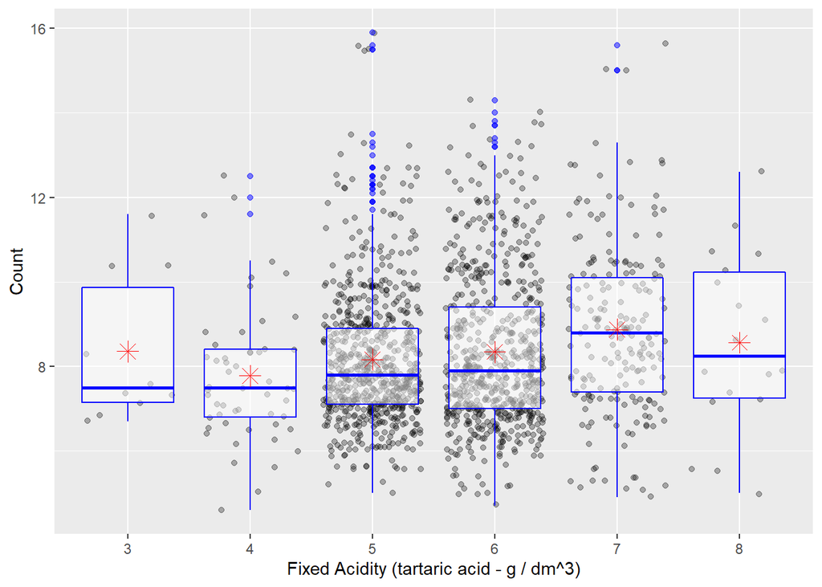

### Citric Acid

#### Bar Chart

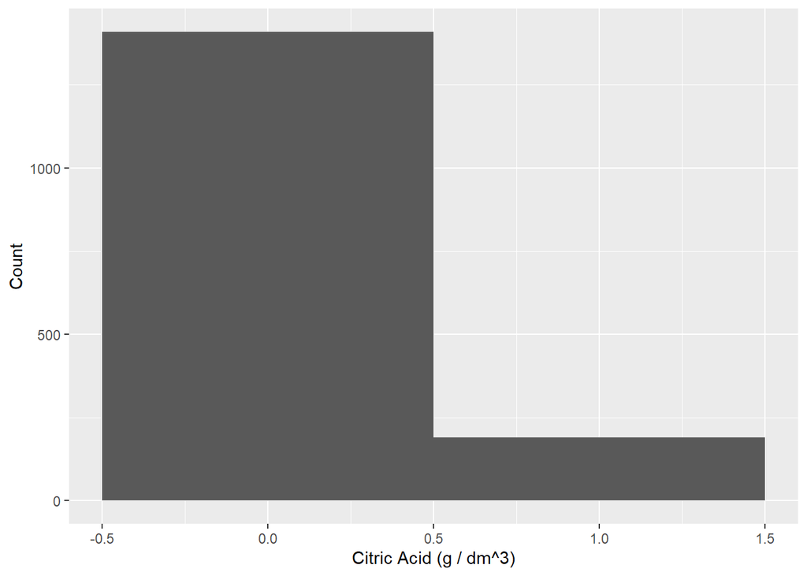

##### I chose a bar chart so we can easily the citric acid content of wines in the dataset.

#### Box Plot with Category Summaries

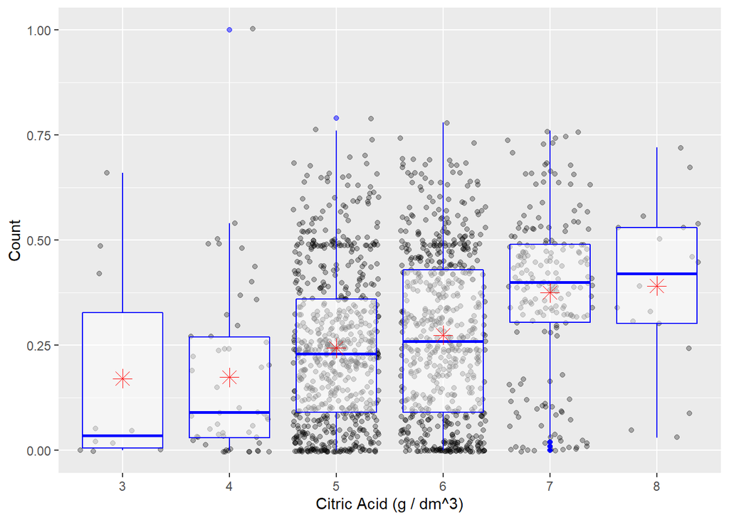

#### This seems in line with our analysis of fixed acidity. Higher ratings tend to have higher citric acid content.

### Residual Sugar

#### Bar Chart

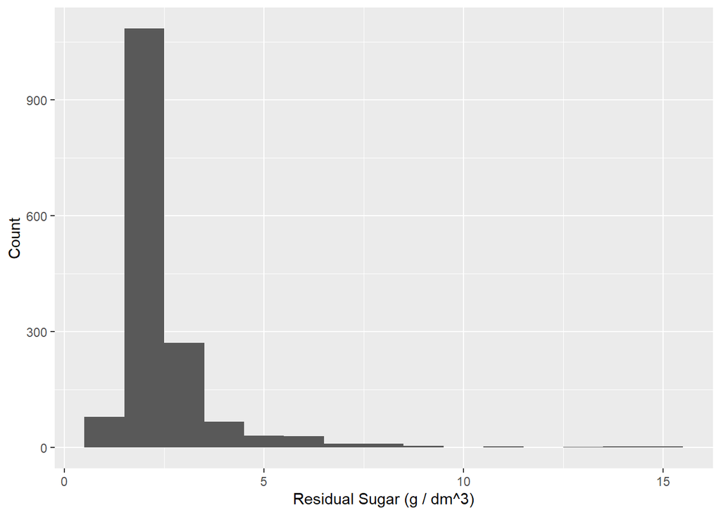

##### I chose a bar chart so we can easily the residual sugar content of wines in the dataset.

#### Box Plot with Category Summaries

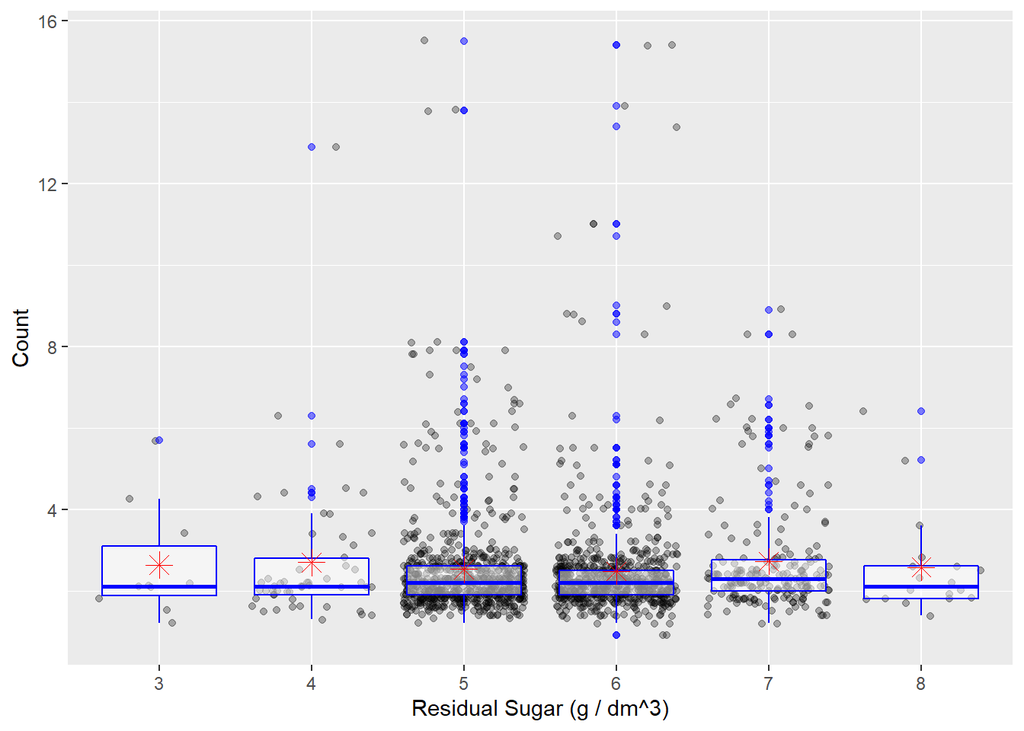

#### It seems as if risidual sugar has minimal impact on quality ratings.

### pH

#### Bar Chart

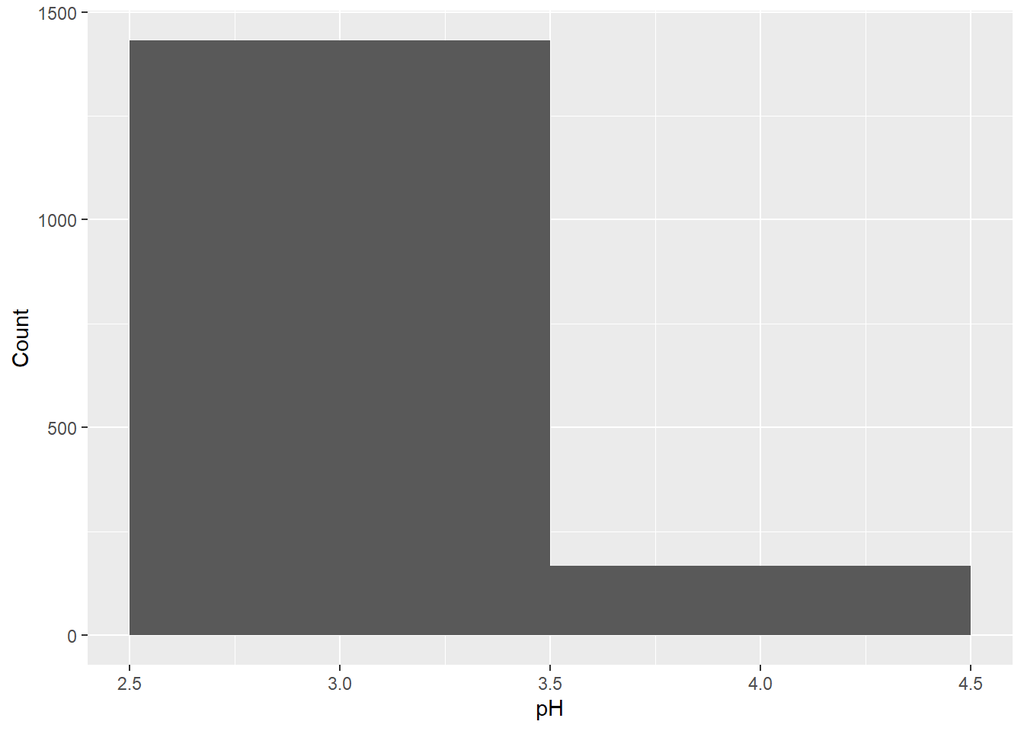

##### I chose a bar chart so we can easily the pH of wines in the dataset.

#### Box Plot with Category Summaries

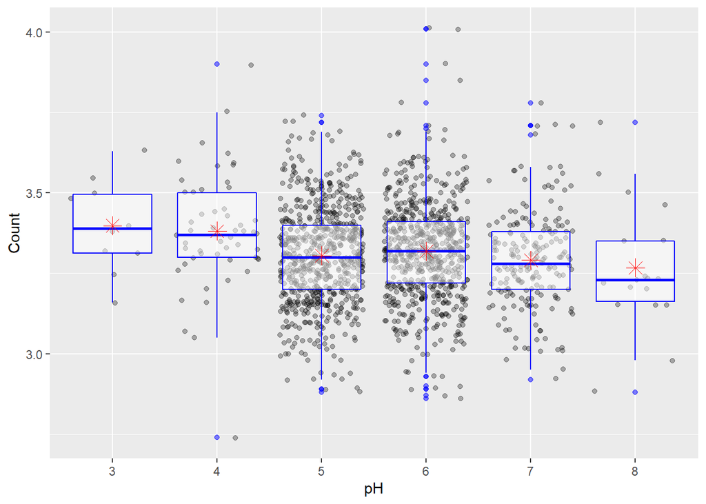

#### pH is a measure of acidity. The lower the pH, the higher the acidity. This is also in line with our findings that higher rated wines tend to have a higher acidity (or lower pH as we see here).

### Total Sulfur Dioxide Content

#### Bar Chart

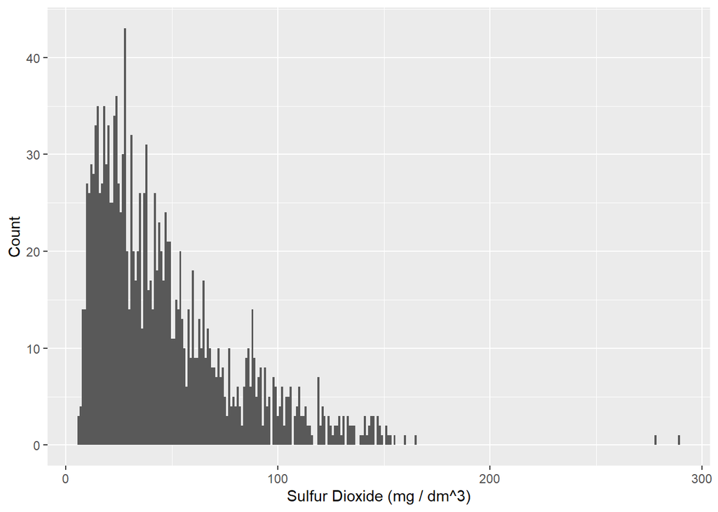

##### I chose a bar chart so we can easily the sulfur dioxide content of wines in the dataset.

#### Box Plot with Category Summaries

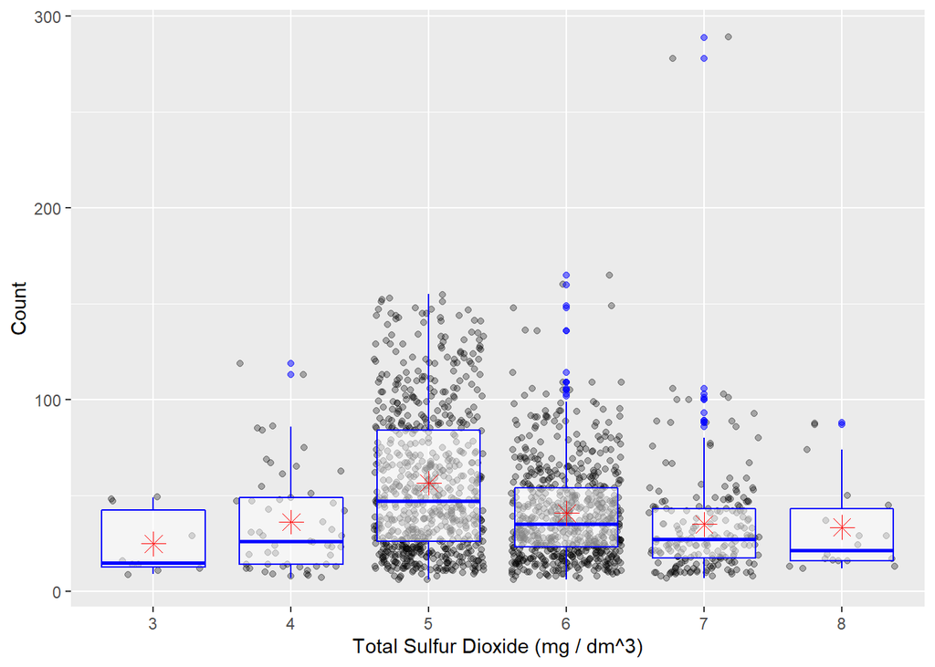

#### Interesting, let’s dig in and take a look at free sulfur dioxide

### Free Sulfur Dioxide and Wine Quality

#### Bar Chart

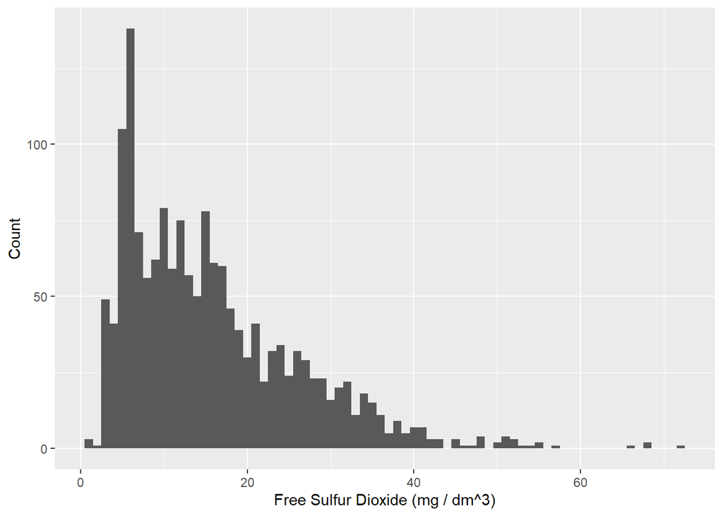

##### I chose a bar chart so we can easily the free sulfur dioxide content of wines in the dataset.

#### Box Plot with Category Summaries

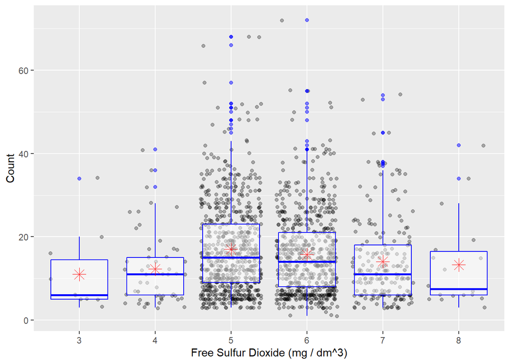

#### This is very similar to the previous plot looking at total sulfur dioxide. THis would be a good rabbit hole to follow in a further analysis.

### Total Sulfur Dioxide and Wine Quality

#### Sulfur Dioxide is used to preserve wine. There are many different views on its use in wine. I am interested in whether the amount of sulfur dioxide impacts quality ratings.

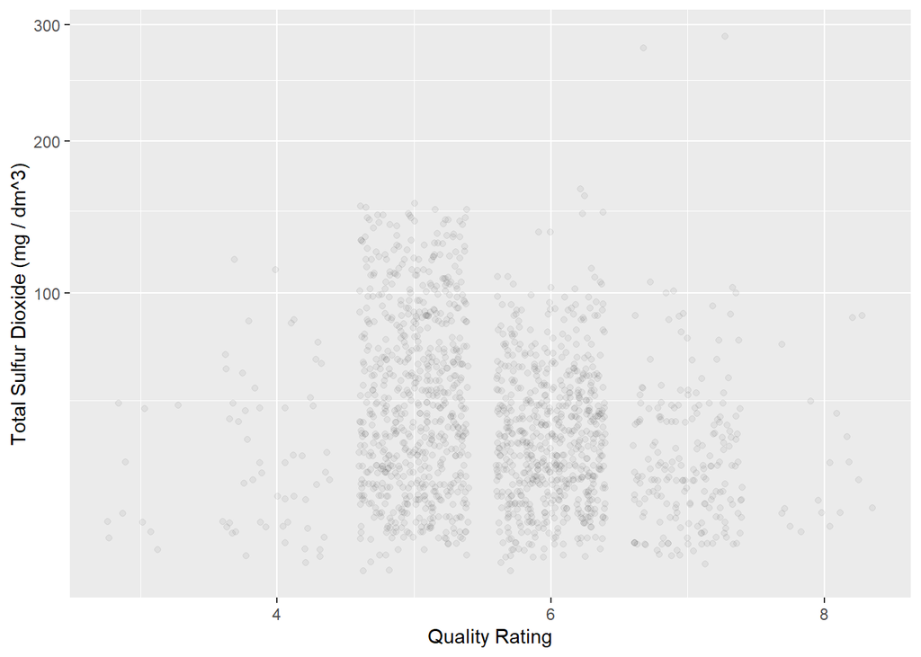

```
##    Min. 1st Qu.  Median    Mean 3rd Qu.    Max.
##    6.00   22.00   38.00   46.47   62.00  289.00
```

### Alcohol and Wine Quality

#### I am interested in whether the amount of alcohol in wine impacts quality ratings.

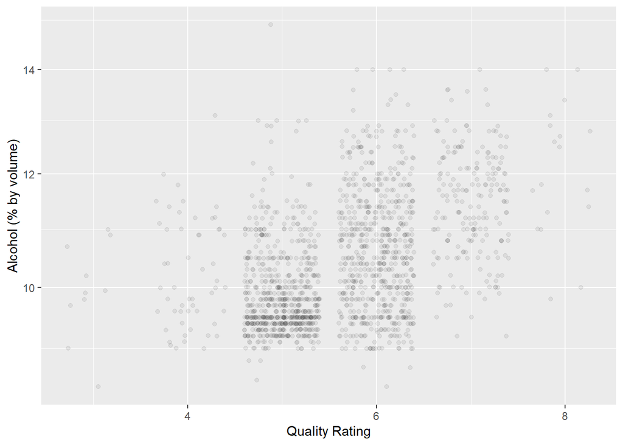

```
##    Min. 1st Qu.  Median    Mean 3rd Qu.    Max.
##    8.40    9.50   10.20   10.42   11.10   14.90
```

#### This scatterplot shows that there is a tendency of wines with a higher rating to contain more alcohol.

### Residual Sugars and Wine Quality

#### I am interested in whether the amount of residual sugar in wine impacts quality ratings.

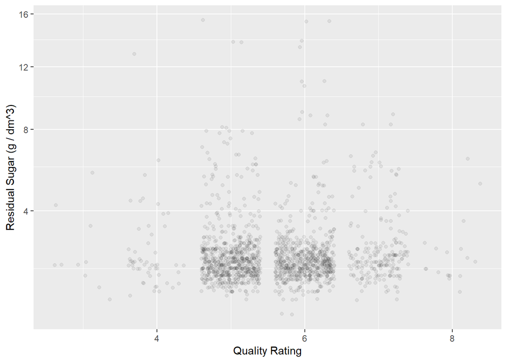

### pH and Wine Quality

#### I am interested in whether the pH of wine impacts quality ratings.

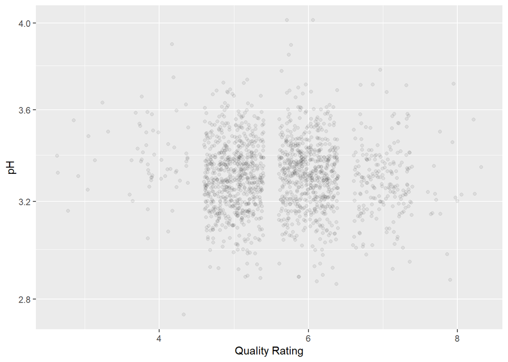

### Alcohol & Sugar’s Impact on Quality

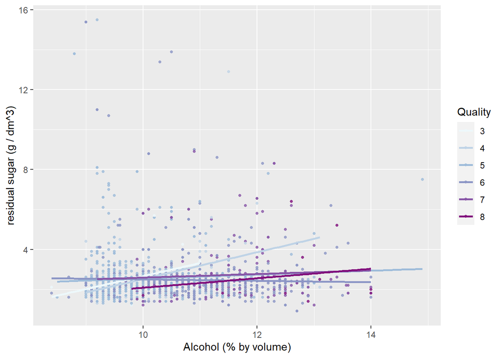

### Chlorides & Sulphates’ Impact on Quality

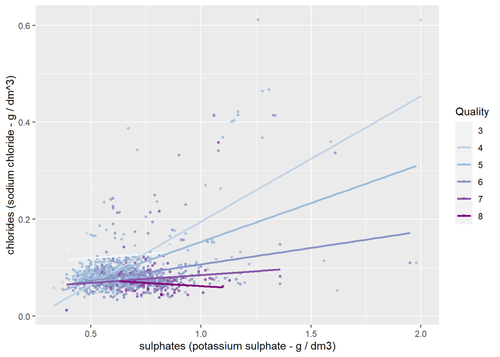

#### Let’s determine our bucket size by looking at the sulphates data.

```
##    Min. 1st Qu.  Median    Mean 3rd Qu.    Max.
##  0.3300  0.5500  0.6200  0.6581  0.7300  2.0000
```

#### WE’ll set our buckets based on the quartiles.

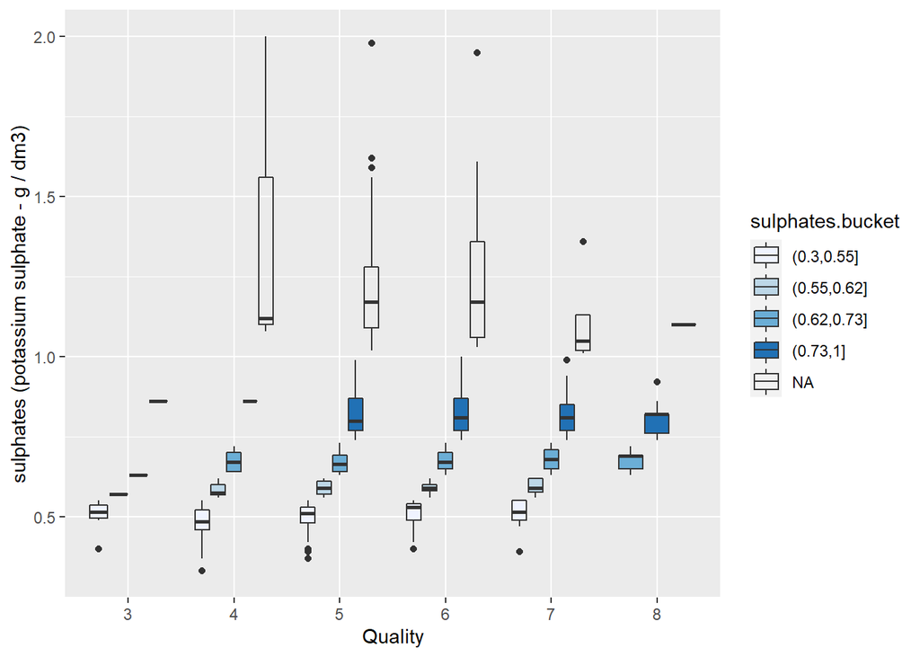

## Final Plots and Summary

##### The following charts represent the most relevant findings of this analysis.

### Alcohol Content

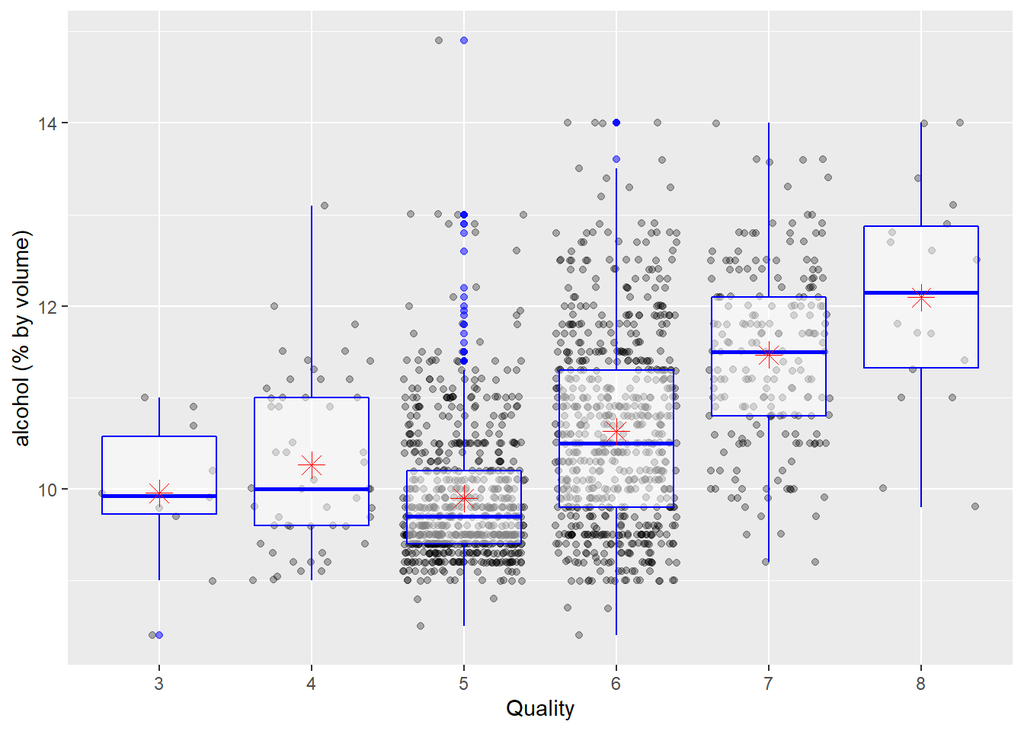

###### The higher the alcohol content the higher the rating.

### Fixed Acidity

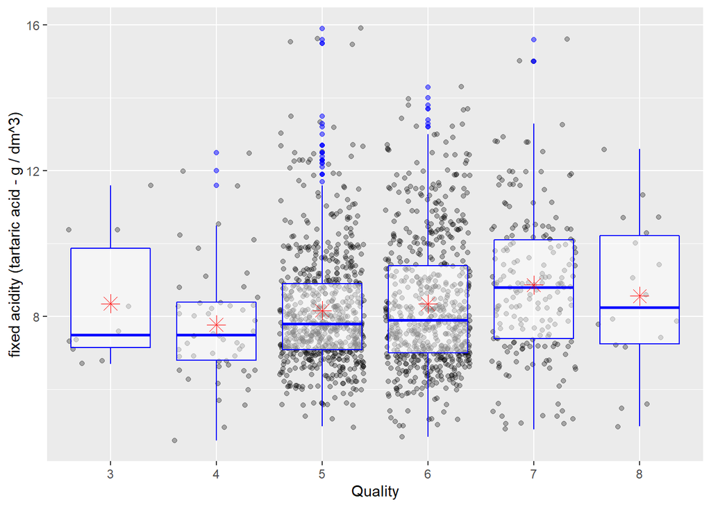

### Chlorides & Sulphates’ Impact on Quality

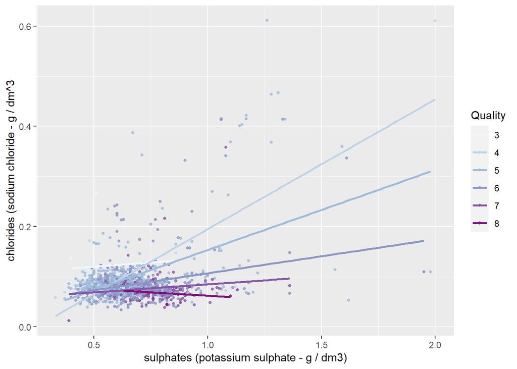

## Reflection

#### For further analysis, I would question whether or not acidity affects wine quality ratings.